# Mountain pine beetles across scales

Author

Simon Frost

## Overview

The mountain pine beetle, *Dendroctonus ponderosae*, has killed pine across millions of hectares of western North America. Its outbreaks join two scales: beetles breed and die within a stand, and disperse between stands. Liu and Estep (2025) built a cellular automaton on a grid of hexagons that couples the two. Within each cell, the number of beetles follows a birth-death process; between cells, the more infested cells of a cluster give up part of their density, which is shared among the cells drawn into the dispersal, some of which fail to establish. The authors explore the patterns this produces: their complexity, how fast they spread, and how they respond to the parameters, to seasons, to barriers and to wind.

This implementation is a **reproduction** of the model as the authors’ released code runs it. Where the code and the article differ, the code is followed and the article’s version is an option; the differences are listed at the end.

```julia
ENV["GKSwstype"] = "100"
using EcologicalCellularAutomata
using CellularAutomataCore
using Plots
using Statistics
```

## The model

The lattice is `m × n` hexagons, odd columns half a cell lower than even ones, with absorbing edges. Each cell holds a normalised beetle density between 0 and 1. A step has two parts:

- **Microscale** (the model’s rule): starting from `density × 100` beetles, 20 independent runs of a birth-death process of 100 small steps each, with births `b x (1 - x/100)` and deaths `d x` per unit time, are averaged.
- **Macroscale** (a callback stored with the problem): the affected cells and their neighbours form an interaction neighbourhood. Each cell is drawn into the dispersal with probability `w d / (1 + w)`, where `w` counts its affected neighbours (plus 1 if affected itself) and `d` is its largest difference in density from a neighbour. Of the cells drawn, those at or above their mean density give up a share `γ₁` of their excess, which is pooled and shared among all of them; the others receive it scaled by `γ₂` and keep it with probability `φ + ρ atan(density)`, or lose all their beetles.

The defaults are the article’s: `b = 1`, `d = 0.2`, `γ₁ = γ₂ = 0.8` and `φ = ρ = 1/3`.

```julia
prob = problem(:mpb_multiscale; seed=1)
size(prob.u0.density), count(>(0), prob.u0.density)
```

```
((50, 50), 45)
```

We draw the hexagons as the source’s code does, and record the two statistics the article studies: the **complexity** of the pattern (edges between affected and unaffected cells per affected cell) and the **radius** of the circle with the affected area, whose change from step to step is the rate of dispersion.

```julia
const HEX = Shape([(cospi(k / 3), sinpi(k / 3)) for k in 0:5])
function hexmap(density; title="", colorbar=false)
    m, n = size(density)
    shapes = [Shape(HEX.x .+ 1.5 * (j - 1), HEX.y .+ sqrt(3) * (i - 1 + 0.5 * iseven(j)))
              for j in 1:n for i in 1:m]
    values = [density[i, j] for j in 1:n for i in 1:m]
    return plot(shapes; fill_z=permutedims(values), c=cgrad(:RdYlGn; rev=true),
                clims=(0, 1), linecolor=:match, linewidth=0, aspect_ratio=1,
                axis=false, ticks=false, legend=false, colorbar, title,
                titlefontsize=9)
end
function track(prob; snapshots=())
    integ = init(prob; save_everystep=false)
    stats = [(complexity=mpb_complexity(integ.u), radius=mpb_radius(integ.u))]
    maps = Dict(0 => copy(integ.u.density))
    while integ.t < prob.tspan[2]
        step!(integ)
        push!(stats, (complexity=mpb_complexity(integ.u), radius=mpb_radius(integ.u)))
        integ.t in snapshots && (maps[integ.t] = copy(integ.u.density))
    end
    return stats, maps
end
logfit(c) = round.([ones(length(c)) 0:(length(c) - 1)] \ log.(c); digits=3)
```

```
logfit (generic function with 1 method)
```

## A spreading infestation

The article’s Fig. 7 follows an infestation for 150 steps from a cluster of 45 cells, with a death rate of 0.4 (from the source’s code):

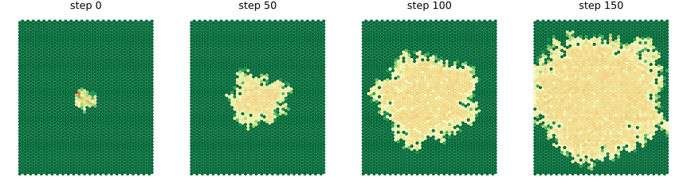

```julia
stats, maps = track(problem(:mpb_multiscale; seed=1, pmap=(; death=0.4));
                    snapshots=(50, 100, 150))
plot([hexmap(maps[t]; title="step $t") for t in (0, 50, 100, 150)]...; layout=(1, 4),
     size=(900, 250))
```

The infestation spreads as a ragged blob with holes, at a density near the microscale’s equilibrium `1 - d/b = 0.6`, and reaches the edges of the grid at about step 150, as in the article.

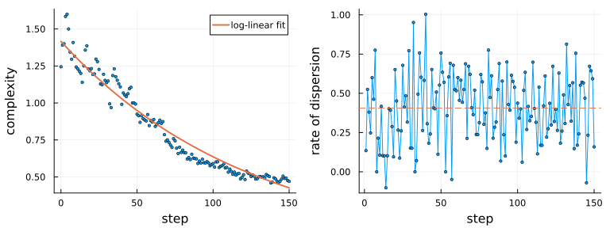

```julia
c = getfield.(stats, :complexity)
rate = diff(getfield.(stats, :radius))
p1 = scatter(0:150, c; ms=2, label="", xlabel="step", ylabel="complexity")
plot!(p1, 0:150, t -> exp(logfit(c)' * [1, t]); lw=2, label="log-linear fit")
p2 = plot(1:150, rate; marker=:circle, ms=2, label="", xlabel="step",
          ylabel="rate of dispersion")
hline!(p2, [mean(rate)]; ls=:dash, label="")
plot(p1, p2; layout=(1, 2), size=(800, 300), left_margin=4Plots.mm,
     bottom_margin=4Plots.mm)
```

```julia
fits = [logfit(getfield.(first(track(problem(:mpb_multiscale; seed=s,
                                                  pmap=(; death=0.4)))), :complexity))
        for s in 1:3]
(fits=fits, early=round.(c[1:6]; digits=2), rate_mean=round(mean(rate); digits=2),
 rate_lag1=round(cor(rate[1:(end - 1)], rate[2:end]); digits=2))
```

```
(fits = [[0.348, -0.008], [0.356, -0.008], [0.306, -0.008]], early = [1.24, 1.39, 1.4, 1.58, 1.6, 1.5], rate_mean = 0.41, rate_lag1 = -0.06)
```

## Three regimes

Depending on the parameters, the article finds infestations that grow without limit, settle to a pattern of roughly fixed size, or fade (its Fig. 10). After 40 steps from a cluster of 53 cells:

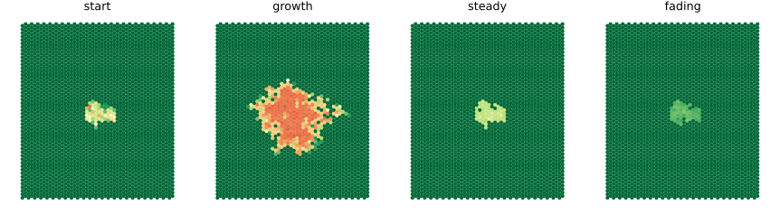

```julia
regimes = [("growth", (; death=0.2, gamma1=0.8, gamma2=0.8)),
           ("steady", (; death=0.6, gamma1=0.4, gamma2=0.2)),
           ("fading", (; death=0.8, gamma1=0.3, gamma2=0.2))]
ends = [track(problem(:mpb_multiscale; pattern=:endings, steps=40, seed=1, pmap=kw);
              snapshots=(40,))[2][40] for (_, kw) in regimes]
plot(hexmap(mpb_pattern(:endings); title="start"),
     [hexmap(e; title=name) for (e, (name, _)) in zip(ends, regimes)]...;
     layout=(1, 4), size=(900, 250))
```

```julia
[(regime=name, affected=count(>(0), e),
  mean_density=round(mean(filter(>(0), e)); digits=2))
 for (e, (name, _)) in zip(ends, regimes)]
```

```
3-element Vector{@NamedTuple{regime::String, affected::Int64, mean_density::Float64}}:
 (regime = "growth", affected = 347, mean_density = 0.67)
 (regime = "steady", affected = 56, mean_density = 0.33)
 (regime = "fading", affected = 51, mean_density = 0.17)
```

As in the article, the first grows, the second keeps its size, and the third keeps its cells at a low density, as its high death rate holds the microscale equilibrium at `1 - 0.8 = 0.2`.

## Parameter sweeps

The article varies one parameter at a time from a common cluster (its Figs 13, 15, 17 and 20) and fits the decline of complexity over 100 steps. One run each, as in the article:

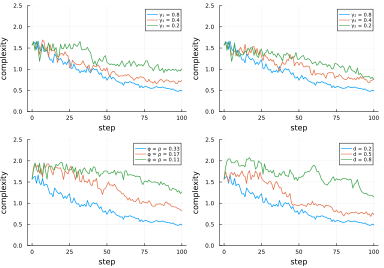

```julia
sweeps = [("γ₁", :gamma1, (0.8, 0.4, 0.2)), ("γ₂", :gamma2, (0.8, 0.4, 0.2)),
          ("φ = ρ", :phi, (1 / 3, 1 / 6, 1 / 9)), ("d", :death, (0.2, 0.5, 0.8))]
function sweep_run(key, v)
    kw = key === :phi ? (; phi=v, rho=v) : NamedTuple{(key,)}((v,))
    return getfield.(first(track(problem(:mpb_multiscale; pattern=:sweep, steps=100,
                                         seed=1, pmap=kw))), :complexity)
end
results = Dict((key, v) => sweep_run(key, v) for (_, key, vs) in sweeps for v in vs)
plot([plot(0:100, [results[(key, v)] for v in vs]; lw=1.5, ylims=(0, 2.5),
           label=permutedims(["$label = $(round(v; digits=2))" for v in vs]),
           xlabel="step", ylabel="complexity", legendfontsize=7)
      for (label, key, vs) in sweeps]...; layout=(2, 2), size=(800, 560))
```

```julia
[(parameter=label, value=round(v; digits=2), fit=logfit(results[(key, v)]))
 for (label, key, vs) in sweeps for v in vs]
```

```
12-element Vector{@NamedTuple{parameter::String, value::Float64, fit::Vector{Float64}}}:
 (parameter = "γ₁", value = 0.8, fit = [0.415, -0.012])
 (parameter = "γ₁", value = 0.4, fit = [0.432, -0.009])
 (parameter = "γ₁", value = 0.2, fit = [0.476, -0.005])
 (parameter = "γ₂", value = 0.8, fit = [0.415, -0.012])
 (parameter = "γ₂", value = 0.4, fit = [0.463, -0.008])
 (parameter = "γ₂", value = 0.2, fit = [0.464, -0.006])
 (parameter = "φ = ρ", value = 0.33, fit = [0.415, -0.012])
 (parameter = "φ = ρ", value = 0.17, fit = [0.708, -0.009])
 (parameter = "φ = ρ", value = 0.11, fit = [0.664, -0.003])
 (parameter = "d", value = 0.2, fit = [0.415, -0.012])
 (parameter = "d", value = 0.5, fit = [0.613, -0.01])
 (parameter = "d", value = 0.8, fit = [0.714, -0.004])
```

The article’s fits of `ln c` are `0.42 - 0.01 t` for the common baseline; `0.53 - 0.01 t` for `γ₁ = 0.4`; `0.5 - 0.01 t` and `0.55 - 0.01 t` for `γ₂ = 0.4` and `0.2`; `0.6 - 0.01 t` for `φ = ρ = 1/6`; and nearly flat declines for `γ₁ = 0.2` (`c = 1.69 - 0.01 t`), `φ = ρ = 1/9` (`c = 1.8 - 0.006 t`) and `d = 0.8` (`c = 1.67 - 0.002 t`). The baseline here matches, and the others agree in direction: dispersing less, surviving dispersal less, or dying more keep a pattern smaller and more ragged.

## Seasons

The article makes the birth rate seasonal, multiplying it by `1 + a sin(2π t/20)` for 20 steps a year (its Fig. 21): `a = 1` in its formula, `a = 2/3` in its code. Within a single cell, left alone, the number of beetles follows the seasons:

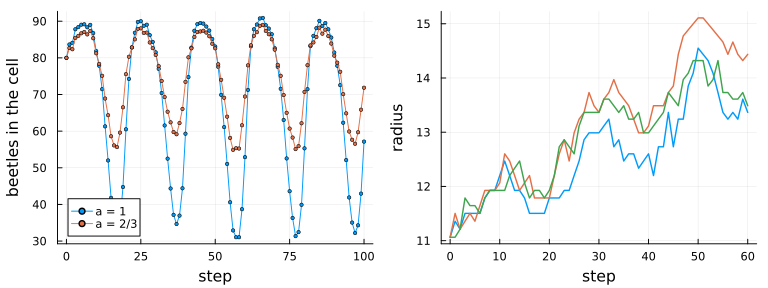

```julia
function lone_cell(amplitude)
    lone = zeros(12, 12)
    lone[6, 6] = 0.8
    integ = init(problem(:mpb_multiscale; pattern=lone, n=12, steps=100, seed=1,
                         pmap=(; schedule=:periodic, amplitude, gamma1=0.0));
                 save_everystep=false)
    beetles = [100 * integ.u.density[6, 6]]
    while integ.t < 100
        step!(integ)
        push!(beetles, 100 * integ.u.density[6, 6])
    end
    return beetles
end
cells = Dict(a => lone_cell(a) for a in (1.0, 2 / 3))
p1 = plot(0:100, [cells[1.0] cells[2 / 3]]; marker=:circle, ms=2,
          label=["a = 1" "a = 2/3"], xlabel="step", ylabel="beetles in the cell",
          legend=:bottomleft)
spread = [getfield.(first(track(problem(:mpb_multiscale; pattern=:sweep, steps=60, seed=s,
                                        pmap=(; schedule=:periodic, death=0.5,
                                              gamma1=0.4, gamma2=0.4, phi=1 / 6,
                                              rho=1 / 6)))), :radius) for s in 1:3]
p2 = plot(0:60, spread; lw=1.5, label="", xlabel="step", ylabel="radius")
plot(p1, p2; layout=(1, 2), size=(800, 300), left_margin=4Plots.mm,
     bottom_margin=4Plots.mm)
```

```julia
(range_a1=round.(extrema(cells[1.0][21:end]); digits=0),
 range_a23=round.(extrema(cells[2 / 3][21:end]); digits=0),
 radius_at_60=round.([s[end] for s in spread]; digits=1))
```

```
(range_a1 = (31.0, 91.0), range_a23 = (55.0, 89.0), radius_at_60 = [13.4, 14.4, 13.5])
```

With the article’s amplitude the cell’s beetles swing between about 31 and 91, as in its Fig. 21a (30 to 85); the code’s amplitude gives a narrower swing. With the code’s amplitude and its settings for this figure (`d = 0.5`, `γ₁ = γ₂ = 0.4`, `φ = ρ = 1/6`), an infestation grows in steps, pausing in the lean season, from a radius of 11 to about 14 in 60 steps, as in the article’s Fig. 21b.

## From endemic to epidemic

The article’s Figs 22 to 24 make both birth and death seasonal, with sharper seasons, and raise the birth amplitude and lower the death amplitude after step 60: a change from an endemic to an epidemic phase. The formulas and values are in the source’s code only.

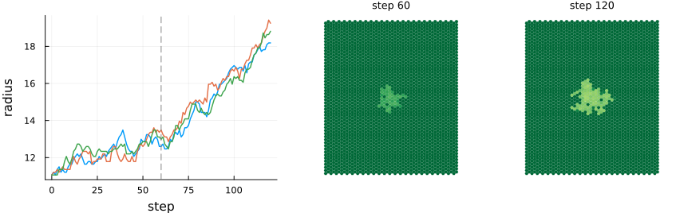

```julia
outbreak = (; schedule=:outbreak, gamma1=0.5, gamma2=0.5, phi=1 / 6, rho=1 / 6)
runs = [track(problem(:mpb_multiscale; pattern=:sweep, steps=120, seed=s, pmap=outbreak);
              snapshots=(60, 120)) for s in 1:3]
p1 = plot(0:120, [getfield.(r[1], :radius) for r in runs]; lw=1.5, label="",
          xlabel="step", ylabel="radius")
vline!(p1, [60]; ls=:dash, color=:gray, label="")
plot(p1, hexmap(runs[1][2][60]; title="step 60"),
     hexmap(runs[1][2][120]; title="step 120"); layout=grid(1, 3; widths=[0.4, 0.3, 0.3]),
     size=(900, 280), left_margin=4Plots.mm, bottom_margin=4Plots.mm)
```

```julia
[(radius_60=round(r[1][61].radius; digits=1), radius_120=round(r[1][121].radius; digits=1))
 for r in runs]
```

```
3-element Vector{@NamedTuple{radius_60::Float64, radius_120::Float64}}:
 (radius_60 = 12.6, radius_120 = 18.2)
 (radius_60 = 13.5, radius_120 = 19.2)
 (radius_60 = 13.0, radius_120 = 18.8)
```

The radius creeps from 11 in the endemic phase and then grows faster, as in the article (about 13 at step 60 and 20 at step 120).

## Barriers and wind

The article blocks dispersal with a barrier pierced by a bridge (its Fig. 18) and biases it with a wind (its Fig. 16). Blocked cells hold no beetles and are no one’s neighbours. With the code’s settings (`d = 0.4`, `γ₁ = γ₂ = 0.6`), an infestation starting west of the barrier:

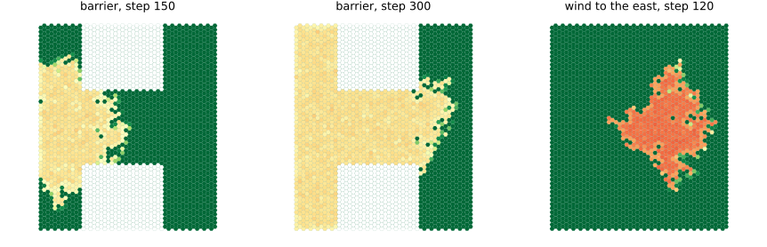

```julia
barrier = falses(50, 50)
barrier[[1:16; 35:50], 13:35] .= true
start = zeros(50, 50)
start[:, 6:10] = mpb_pattern(:sweep)[:, 22:26]
column9 = view(start, :, 9)
column9[column9 .== 0.8] .= 0.4
wall = track(problem(:mpb_multiscale; pattern=start, blocked=barrier, steps=300, seed=1,
                     pmap=(; death=0.4, gamma1=0.6, gamma2=0.6)); snapshots=(150, 300))[2]
windy = track(problem(:mpb_multiscale; pattern=:sweep, steps=120, seed=1,
                      pmap=(; wind=:east, gamma1=0.6, gamma2=0.6)); snapshots=(120,))[2]
shade(d) = ifelse.(barrier, NaN, d)
plot(hexmap(shade(wall[150]); title="barrier, step 150"),
     hexmap(shade(wall[300]); title="barrier, step 300"),
     hexmap(windy[120]; title="wind to the east, step 120"); layout=(1, 3), size=(900, 290))
```

The barrier (blank) leaves the infestation only the bridge to cross. The wind towards the east keeps low-density cells upwind out of the dispersal, so the infestation grows only eastwards: the mean column of its cells, with and without wind, from the start’s 25:

```julia
centre(u) = round(mean(I[2] for I in findall(>(0), u)); digits=1)
calm = track(problem(:mpb_multiscale; pattern=:sweep, steps=120, seed=1,
                     pmap=(; gamma1=0.6, gamma2=0.6)); snapshots=(120,))[2]
(wind=centre(windy[120]), calm=centre(calm[120]))
```

```
(wind = 33.9, calm = 24.8)
```

## Deviations from the source

```julia
foreach(d -> println("- ", d), model_info(:mpb_multiscale).deviations)
```

[output not shown]

## References

Liu, Yanjun, and Donald Estep. 2025. “A Multiscale Stochastic Cellular Automata Model for Dispersion of Mountain Pine Beetles.” *Royal Society Open Science* 12 (6): 241934. https://doi.org/10.1098/rsos.241934.